# Documentation - Becoming an economist: France

Authors

Affiliations

Thomas Delcey

Université de Bourgogne

Aurelien Goutsmedt

UC Louvain; ICHEC

Published

November 24, 2026

[figure not shown]

# Introduction

This database compiles information on Ph.D. dissertations in economics defended in France since 1900.[^1]

The French database is implemented as a relational database that integrates multiple interconnected data frames. It is organized around four main components:

- **Thesis Metadata:** This table contains the core information for each dissertation. Each entry corresponds to a single thesis and includes details such as the title, defense date, abstract, and other relevant metadata.
- **Edges Data:** This table captures the connections between the other three tables, linking individuals, institutions, and theses. It associates each thesis with the individuals and institutions involved in its production, thereby enabling a synthetized view of these relationships.[^2]
- **Institutions Data:** This table includes information on universities, laboratories, doctoral schools, and other institutions associated with the dissertations. Each entry corresponds to a single institution.
- **Individual Data:** This table contains information on the individuals involved in the dissertations, including authors, supervisors, and jury members. Each entry corresponds to a single individual.

## Sources

The data used in this project comes from three mains sources:

- **Theses.fr:** https://theses.fr/
- **Sudoc:** https://www.sudoc.fr/
- **IdRef:** https://www.idref.fr/

These sources are the result of the work of the [ABES](https://abes.fr/l-abes/presentation/) (l’Agence bibliographique de l’enseignement supérieur) who produced metadata and APIs regarding research and superior education. The data of the three sources mentionned above are under the [Etabab “Open Licence”](https://www.etalab.gouv.fr/licence-ouverte-open-licence/).[^3]

- [Theses.fr](https://theses.fr/) is a comprehensive repository for PhD dissertations defended in French institutions since 1985.[^4] It includes metadata such as the title of the dissertation, author, date of defense, institution, supervisor, abstract, etc. The database covers a wide range of disciplines, providing access, in some cases, to digital theses.
- [Sudoc](https://www.Sudoc%20.fr/) stands for “*Système Universitaire de Documentation*”. It is a union catalog that includes references to various documents held in French academic and research libraries. It covers books, journal articles, dissertations, and other academic works. The Sudoc database includes metadata like title, author, publication date, and library locations where the documents can be found. It is a key resource for academic research in France, providing a broad overview of available scholarly materials. Regarding PhD, it allows to find dissertations defended before 1985, and to recover relevant metadata.
- [IdRef](https://www.idref.fr/) stands for “*Identifiants et Référentiels pour l’Enseignement supérieur et la Recherche*”. It is a database focused on managing and standardizing the names and identifiers of authors and other contributors to academic and research works. It provides authority control for names used in academic cataloging, ensuring consistency and aiding in accurate attribution of works. IdRef is used in conjunction with Sudoc and other databases to support the management of bibliographic data in the French higher education and research sectors. In our project, it allows us to find additional data on individuals and institutions.

Our data-building approach focuses on ensuring consistency and quality while preserving the integrity of the original information. We relies on two principles to build this database:

- **No Data transformation**: Our work primarily involves data collection, categorization, and cleaning. We intentionally minimized transformations, restricting them to only minor and non-impactful adjustments. Specifically, we avoided altering the cell values of the original data, instead encoding any modifications in new columns.[^5] The complete edges data frame keeps a track of our transformations.
- **Disambiguation**: We aimed to disambiguate theses and associated entities (individuals and institutions) as thoroughly as possible. Disambiguation involves identifying and distinguishing between entries with similar descriptions. This process is essential to avoid duplicated data or to merge distinct entries. To address this, we assigned a unique identifier to each entity. The identifiers provided by the Agence Bibliographique de l’Enseignement Supérieur (ABES) through IdRef served as our primary source for unique identifiers. In cases where ABES identifiers were unavailable, we generated our own unique identifiers to maintain consistency and accuracy.

## Usage and Access

Our database is released under the [CC-BY-4.0 licence](https://creativecommons.org/licenses/by/4.0/). allowing free access and use by anyone. The data is hosted in a [Zenodo repository](https://doi.org/10.5281/zenodo.14541426). While the database focuses on Ph.D. dissertations in economics and queries sources based on the field of the thesis, the scripts have been designed with flexibility. They can be adapted for other queries involving notably different disciplines.

If you use our data or scripts, please cite the following reference: “Delcey Thomas, and Aurélien Goutsmedt. (2024). Becoming an Economist: A Database of French Economics PhDs. Zenodo. https://doi.org/10.5281/zenodo.14541426”

```
@article{
  title={Becoming an Economist: A Database of French Economics PhDs},
  author={Delcey, Thomas and Goutsmedt, Aurélien},
  journal={Zenodo},
  year={2024},
  doi={https://doi.org/10.5281/zenodo.14541426}
}
```

**WarningCode usages**

Note that some of our data cleaning steps are tailored to the specific characteristics of the datasets we extracted. We systematically identified issues in our data and applied manual cleaning processes, such as removing problematic titles, identifying duplicates, and standardizing institutional names.

If you use our code to extract data, it is essential to carefully assess the quality of your extracted data and adapt the cleaning steps accordingly. Feel free to reach out to us for guidance if you plan to use our code for similar data extraction tasks.

# Presentation of the tables

## Thesis Metadata

The `thesis_metadata` table contains 20 variables:

- `thesis_id`: the unique identifier of the thesis. If it exists, it is the official “national number of the thesis” created by the ABES and the theses.fr website. If not, it is a temporary identifier we have created.
- `year_defence`: the year of the thesis defense. Our database covers the period 1899-2023.
- `author`: the first name and last name of the author of the thesis.
- `author_id`: the identifier of the author. If it exists, it is the official “idref” created by the ABES. If not, it is a temporary identifier we have created.
- `title_fr`: the title of the thesis in French.
- `title_en`: the title of the thesis in English.
- `title_other`: the title of the thesis in another language.
- `abstract_fr`: the abstract of the thesis in French.
- `abstract_en`: the abstract of the thesis in English.
- `abstract_other`: the abstract of the thesis in another language.
- `language` and `language_2` are the languages of the thesis. The variable is harmonized to make the information on language found in Sudoc and These.fr compatible.
- `institution_thesis_name`: the name of the institution where the thesis was defended. The name is standardized using IdRef preferred name.
- `institution_thesis_id`: the identifier of the institution where the thesis was defended. If it exists, it is the official “idref” created by the ABES. If not, it is a temporary identifier we have created.
- `country`: the country where the thesis was defended, i.e. France.
- `field`: the field of the thesis (such as “Sciences économiques”). The field remains unaltered by our work and can take on a wide range of values, as indicated by the number of distinct entries (696).
- `type`: the type of the thesis. Type can take 6 values: Thèse, Thèse d’État, Thèse complémentaire, Thèse de 3e cycle, Thèse de docteur-ingénieur, Thèse sur travaux. All categories are derived from categories found in Sudoc.
- `accessible`: a binary variable indicating whether the fulltext is accessible or not (data coming only from theses.fr).
- `url`: the url of the thesis on [theses.fr](https://theses.fr/) or [Sudoc](https://www.sudoc.fr/) websites
- `duplicates`: a list of `thesis_id` that indicate duplicated thesis. We identified duplicates but did not remove them to preserve the maximum information from the raw sources. This variable allows users to handle duplicates using their preferred strategy.

**NoteTemporary identifiers**

When we were unable to provide an ABES identifiers for a thesis or entity, we created our own unique “temporary identifiers” coded as follows `temp_X_Y`, X representing the source of the original information (either “sudoc” or “thesesfr”), Y the type of record (“thesis”, “individual” or “institution”), followed by a hash of the record (for a thesis, its Sudoc url; for an entity, the thesis identifier, its role, name and first name). The same record thus keeps the same identifier from one version of the database to the next (before November 2026, these identifiers were random numbers regenerated at each update). We refer to these identifiers as temporary because they may be replaced in future updates by ABES identifiers, either as ABES updates its sources or as we improve our cleaning process.

**Warning`Language`**

The `language` variables may be important for exploring issues related to the internationalization of economics. However, the raw source data exhibited a notable error rate in the classification of title and abstract languages: French titles were frequently mislabeled as English, and vice versa. To address this issue, we employed language prediction models to correct the misclassified information when possible. For a detailed explanation of the cleaning process, refer to Section 3.2.4.

Table 1 shows a sample of the thesis metadata table. The thesis metadata table contains 21025 theses. Figure 1 shows the distribution of theses over time.

Table 1: Sample of the metadata table

| thesis_id | year_defence | author | author_id | title_fr | title_en | title_other | abstract_fr | abstract_en | abstract_other | language | language_2 | institution_thesis_name | institution_thesis_id | country | field | type | accessible | url | duplicates |
| --- | --- | --- | --- | --- | --- | --- | --- | --- | --- | --- | --- | --- | --- | --- | --- | --- | --- | --- | --- |
| 2020REIME001 | 2020 | Ivan, Mitrouchev | 252397282 | Essais sur l'économie comportementale normative... | Essays on normative behavioural economics : met... |  | Cette thèse est un recueil de cinq chapitres qu... | This thesis is a collection of five chapters wh... |  | en |  | Université de Reims Champagne-Ardenne (1967-....) | 026403838 | France | Sciences économiques et de gestion | Thèse | oui | https://theses.fr/2020REIME001 | [None] |
| 2002IEPP0044 | 2002 | Beethoven, Herrera Valencia | 077323408 | Mondialisation économique : le processus réel e... |  |  |  |  |  | fr |  | Institut d'études politiques (Paris ; 1945-....) | 027918459 | France | Sciences économiques | Thèse | non | https://theses.fr/2002IEPP0044 | [None] |
| temp_sudoc_thesis_dcc3257fa53f8fc8 | 1984 | Rigobert, Maboundou | 26842859X | La formation des prix agricoles au Congo |  |  |  |  |  | fr |  | Université des sciences sociales (Grenoble ; 1970-1990) | 103961852 | France | Sciences économiques | Thèse de 3e cycle |  | https://www.sudoc.fr/041219724 | [None] |
| 2002NICE0065 | 2002 | Nabil, Maalel | 080077846 | Libéralisation de l'agriculture dans les pays e... |  |  |  |  |  | fr |  | Université de Nice (1965-2019) | 026403498 | France | Sciences économiques | Thèse | non | https://theses.fr/2002NICE0065 | [None] |
| 1966REN0G001 | 1966 | Claude, Geffroy | 128731893 | Analyse économique du fait publicitaire |  |  |  |  |  | fr |  | Université de Rennes. Faculté de droit et des sciences économiques (1896-1969) | 035647191 | France | Sciences économiques | Thèse |  | https://www.sudoc.fr/084394242 | [None] |
| 2012AIXM1088 | 2012 | Marc, Girel | 175950962 | Approche exploratoire d’une possible évaluation... | Exploratory approach of a possible evaluation m... |  | L'Investissement Socialement Responsable (ISR) ... | The Socially Responsible Investment (SRI) is a ... |  | fr |  | Aix-Marseille Université (2012-....) | 15863621X | France | Sciences économiques | Thèse | non | https://theses.fr/2012AIXM1088 | [None] |
| 2011IEPP0035 | 2011 | Erik, Van Der Marel | 163766878 | Du commerce, de la productivité et de la régula... | On trade, productivity and regulation in services |  | Cette thèse se penche sur les liens entre la pr... | This dissertation examines the links between pr... |  | en | fr | Institut d'études politiques (Paris ; 1945-....) | 027918459 | France | Sciences économiques | Thèse | non | https://theses.fr/2011IEPP0035 | [None] |
| 2011POIT4001 | 2011 | Émilie, Bourdu | 170021769 | L'évaluation des dispositifs institutionnels te... | Evaluation of Local Institutional Arrangements ... |  | Les marchés locaux du travail sont caractérisés... | Local labour markets are characterized by misma... |  | fr |  | Université de Poitiers (1896-...) | 026403765 | France | Sciences économiques | Thèse | non | https://theses.fr/2011POIT4001 | [None] |
| 1992IEPP0018 | 1992 | Jong Soon, Yim | temp_thesefr_individual_71ee35c6df88a3c8 | Le Système monétaire européen et son environnem... | The European monetary system and its internatio... |  | Les pays membres du SME se trouvent affrontés a... | The EMS countries confront the macroeconomic in... |  | fr |  | Institut d'études politiques (Paris ; 1945-....) | 027918459 | France | Sciences économiques | Thèse | non | https://theses.fr/1992IEPP0018 | [None] |
| temp_sudoc_thesis_9e694a68ad8d7d38 | 1940 | Louis B., Kovèss | 095617736 | La mine d'or et ses mineurs de quelques aspects... |  |  |  |  |  | fr |  | Université de Paris (1896-1968). Faculté de droit et des sciences économiques | 034925732 | France | Sciences économiques | Thèse |  | https://www.sudoc.fr/02514460X | [None] |

[output cut: 40 more lines]

**Distribution of theses**

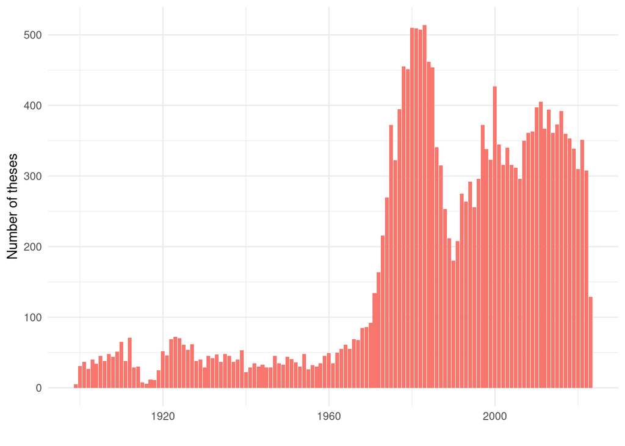

Figure 1: Distribution of theses by defense date

**Distribution of theses by type**

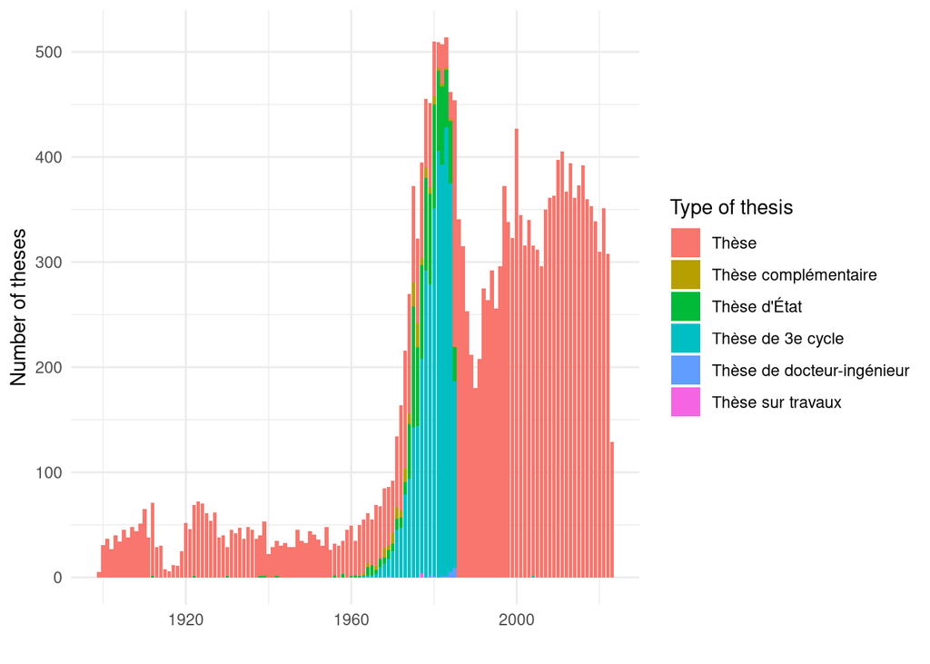

Figure 2: Distribution of theses by defence date and type of thesis

**Availability of abstracts**

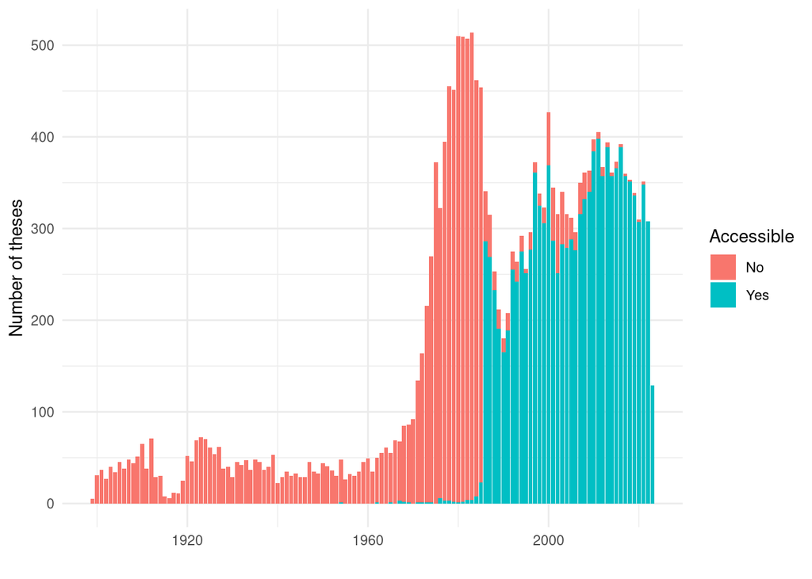

Figure 3: Distribution of theses by the availability of abstracts

**NoteThe variable `type`**

The French education system lacked a standardized Ph.D. system between the early 1960s and 1984, the year of the Savary reform, which harmonized the Ph.D. system. During this period, various types of theses coexisted. For instance, in the mid-1970s, it was common for scholars to first complete a “Doctorat de 3e cycle” before pursuing a “Doctorat d’État.” As a result, a single author may have produced multiple types of theses. Figure 2 illustrates the distribution of theses over time, categorized by type. It should also be noted that the inclusion of thesis type in the metadata is not systematically ensured. This variability depends on the quality of metadata provided by individual institutions, which may affect the reliability of classification.

**WarningAvailability of `abstracts`**

The practice of providing abstracts started in the 1980s. Prior to this period, abstracts were missing (see Figure 3).

## Edges

Each line in the `thesis_edge` table represents a unique edge between a thesis and an entity. We define an *entity* as any individual or institution involved in the thesis. The edge table has five 5 columns:

- `thesis_id`: the identifier of a thesis (the same as in thesis_metadata). In the edge table, a `thesis_id` can have several edges. A `thesis_id` has *at least* two edges: the author and the institution where the thesis was defended.
- `entity_id`: the identifier of an entity. If it exists, it is the official “idref”, an unique identifiers created by the ABES (see https://www.idref.fr/). If not, it is a temporary identifier we have created following the strategy we used for `thesis_id`.
- `entity_role`: the role of the entity. An individual, for example, may serve as an author, supervisor, referee, president, or jury member. In addition to identifying the primary institution where the Ph.D. was defended, the `entity_role` variable may include supplementary information we collected, such as affiliations with other institutions, laboratories, or doctoral schools (the organizations responsible for overseeing doctoral programs in French universities). This detailed information primarily applies to theses recorded in theses.fr after 1985. For data sourced from Sudoc, the value “etablissements_soutenance_from_info” of `entity_role` may provide additional information regarding the institutions associated with the thesis.
- `entity_name`: The name of the entity. It is derived from the preferred name in the official IdRef notice, or from raw information when the entity has no IdRef. See Section 3.2.5 and Section 3.2.6 for more information about names standardization.
- `entity_firstname`, the first name of the individual. Coded as missing value when the entity is an institution.

**NoteEntity identifiers**

Through the https://www.idref.fr/ platform, the ABES assigns unique identifiers to institutions and individuals involved in research in France. This system provides valuable information about entities, such as their dates of existence and the various names used to refer to entities. For example, see the entry for the former [University of Paris](https://www.idref.fr/034526110) that split after 1968. We scrapped those information to enrich our institution and individual tables (see Section 3.1.3).

Table 2 shows a sample of the thesis edge table. We identify 100813 edges in total. Figure 4 shows the distribution of individuals by role. Figure 5 shows the distribution of individuals for the top institutions.

Table 2: Sample of the edges table

| thesis_id | entity_id | entity_role | entity_name | entity_firstname |
| --- | --- | --- | --- | --- |
| 1923BORUD005 | 153480777 | author | Gachitch | Yovan |
| 1923BORUD005 | 030142199 | institution_defence | Université de Bordeaux (1441-1970) |  |
| 1923BORUD005 | 028949145 | member | Pirou | Gaëtan |
| 1923BORUD005 | 030415705 | member | Palmade | Maurice |
| 1923BORUD005 | 060856076 | member | Benzacar | Joseph |
| 1923BORUD005 | 060856076 | president | Benzacar | Joseph |
| 1923BORUD005 | 129104000 | research_partner | Université de Bordeaux. Faculté de droit (1870-1970) |  |
| 1974BOR1D015 | 034750703 | author | Goulvestre | Jean-Paul |
| 1974BOR1D015 | 027548341 | institution_defence | Université Bordeaux-I (1971-2013) |  |
| 1974BOR1D015 | 026820641 | member | Delfaud | Pierre |

[output cut: 53 more lines]

**Top roles**

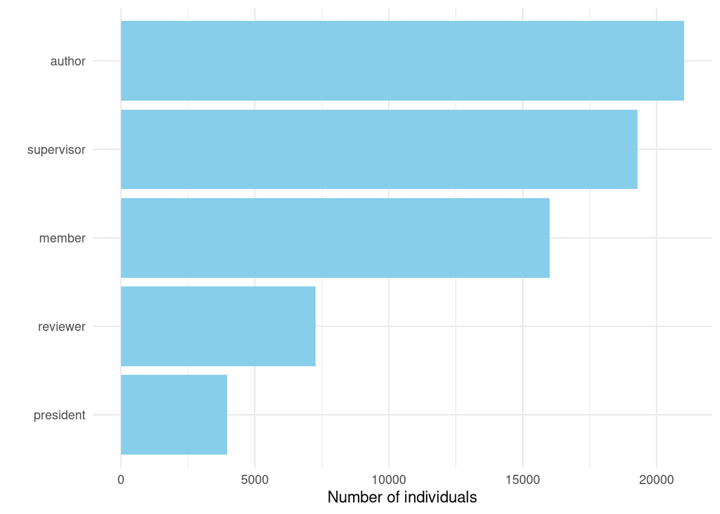

Figure 4: Top role

**Top institutions**

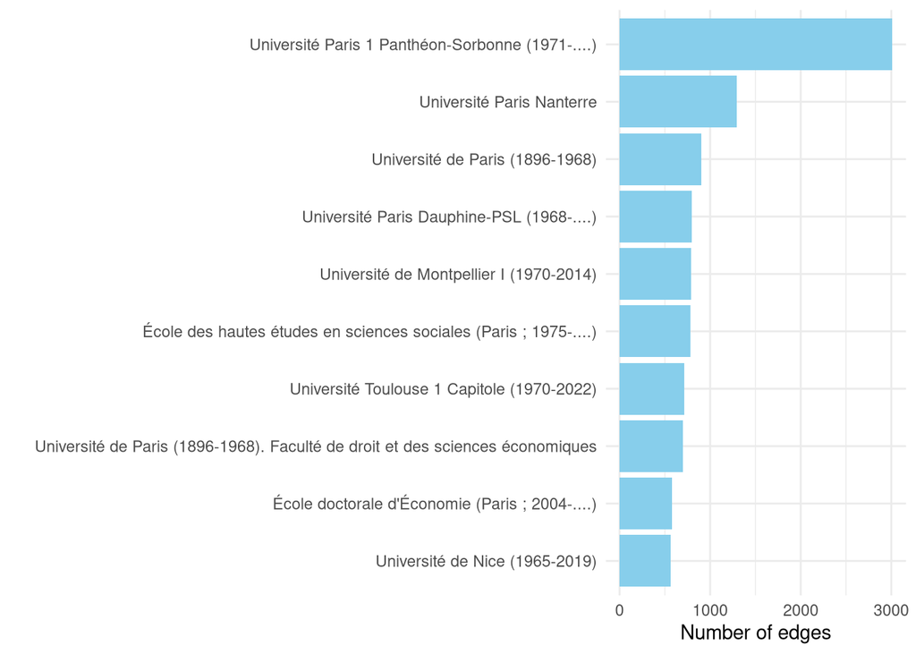

Note that the two figures represent the raw count of observations in the edge table and do not account for thesis duplicates. For example, to determine the exact number of theses published by the Université Paris I Panthéon-Sorbonne, it is necessary to first address duplicates in the metadata tables. This can be achieved by merging entries identified as duplicates using the `duplicates` column.

### Complete Edges Data

The `thesis_edge_complete_data` allows the comparison between original data as collected on theses.fr and sudoc with the results of our cleaning process. In addition to the columns of `thesis_edge`, we have 4 additional columns:

- `original_id`: the original identifier of the entity in the raw data. This allows to see how temporary identifiers for institutions have been cleaned to find the official idref.
- `original_entity_name`: the name of the entity as in the original raw data.
- `original_entity_firstname`: the first name of the individual as in the original data source.
- `source`: the source of the data. It can be “thesesfr” or “sudoc”.

Table 3 shows a sample of the additional information contained in the `thesis_edge_complete` table.

| thesis_id | entity_id | original_id | entity_role | entity_name | entity_firstname | original_entity_name | original_entity_firstname | source |
| --- | --- | --- | --- | --- | --- | --- | --- | --- |
| 1987PA020090 | 033228868 |  | author | Scannavino | Aimé | Scannavino | Aimé | thesesfr |
| 1987PA020090 | 026403145 | 026403145 | institution_defence | Université Panthéon-Assas (Paris ; 1970-2021) |  | Paris 2 |  | thesesfr |
| 1987PA020090 | 026861992 |  | supervisor | Fericelli | Anne-Marie | Fericelli | Anne-Marie | thesesfr |
| temp_sudoc_thesis_a794edc4698e2d91 | temp_sudoc_individual_f450fc74cce9679c |  | author | Savel | Frederique | SAVEL | FREDERIQUE | sudoc |
| temp_sudoc_thesis_a794edc4698e2d91 | 027361802 | 027361802 | institution_defence | Université Paris 1 Panthéon-Sorbonne (1971-....) |  | Université Paris 1 Panthéon-Sorbonne |  | sudoc |
| temp_sudoc_thesis_a794edc4698e2d91 | 058609172 |  | supervisor | Parent | Jean | Parent | Jean | sudoc |
| temp_sudoc_thesis_a96a2877bdf15d3e | temp_sudoc_individual_053214100672e9c1 |  | author | Goepfert | René | Goepfert | René | sudoc |
| temp_sudoc_thesis_a96a2877bdf15d3e | 034925732 | 034925732 | institution_defence | Université de Paris (1896-1968). Faculté de droit et des sciences économiques |  | Université de Paris |  | sudoc |
| temp_sudoc_thesis_a96a2877bdf15d3e | 034526110 | temp_sudoc_institution_62e5c67458ee0410 | institution_defence_from_info | Université de Paris (1896-1968) |  | Paris |  | sudoc |

## Institutions

- `entity_id`: the unique identifier of the entity (here the institution).
- `entity_name`: the name of the entity. When an IdRef exists, the `entity_name` comes from the `pref_name` variable of the IdRef database.
- `old_id` : the list of the temporary identifiers of the entity that has been merged with the `entity_id` (see Section 3.2.5 for details on the cleaning process).

The other variables are additional information on the institutions scrapped on [IdRef](https://www.idref.fr/):

- `url`: the IdRef url of the entity.
- `other_labels`: other labels of the entity.
- `date_of_birth`: the date of creation of the entity.
- `date_of_death`: the date of disappearance of the entity.
- `information`: additional information on the entity.
- `replaced_idref`: the identifier of the entity that replaced the entity.
- `predecessor`: the predecessor of the entity.
- `predecessor_idref`: the identifier of the predecessor of the entity.
- `successor`: the successor of the entity.
- `successor_idref`: the identifier of the successor of the entity.
- `subordinated`: list of the entities subordinated to the entity.
- `subordinated_idref`: list of the identifiers of the entities subordinated to the entity.
- `unit_of`: the entities to which the entity in question is a unit of.
- `unit_of_idref`: the identifier of the entities to which the entity in question is unit of.
- `other_link`: other links of the entity.
- `country_name`: the country of the entity.

**WarningHandling institutions without identifier**

Table 4 shows a sample of the `thesis_institution` table.

Table 4: Sample of the thesis institution table

| entity_id | entity_name | old_id | url | other_labels | date_of_birth | date_of_death | information | replaced_idref | predecessor | predecessor_idref | successor | successor_idref | subordinated | subordinated_idref | unit_of | unit_of_idref | other_link | country_name |
| --- | --- | --- | --- | --- | --- | --- | --- | --- | --- | --- | --- | --- | --- | --- | --- | --- | --- | --- |
| 026375273 | Télécom Paris (Palaiseau, Essonne ; 1878-....) | [None] | https://www.idref.fr/026375273.rdf | c("ENST (Paris) -- (1942-2007)", "École nationale supérieure des télécommunic... | 1878 |  | c("Télécom Paris est un établissement public à caractère scientifique, cultur... | 186107218 | École nationale supérieure des postes et télécommunications | 026375265 | [] | [] | [] | [] | ['Institut Mines-Télécom', 'Université Paris-Saclay', 'Institut polytechnique de Paris'] | ['192427156', '188120777', '238327159'] | ['https://data.hal.science/structure/1048346#foaf:Organization', 'https://ror.org/01naq7912#foaf:Organization', 'http://isni.org/isni/0000000121096951', 'http://data.bnf.fr/ark:/12148/cb11863493k#foaf… | France |
| temp_sudoc_institution_c68abe419732ea3c | Lille | [None] |  |  |  |  |  |  |  |  |  |  |  |  |  |  |  |  |
| 183948173 | Centre d'économie et de management de l'océan Indien (Saint-Denis, Réunion) | [None] | https://www.idref.fr/183948173.rdf | c("CEMOI", "Équipe d'accueil (EA13)", "Université de la Réunion. Centre d'éco... | 2010-01-01 |  | CEMOI = Centre d'économie et de management de l'océan Indien | [] | [] | [] | [] | [] | [] | [] | [] | [] | http://viaf.org/viaf/314928916 |  |
| 074038567 | Université de Bourgogne. URF des sciences et techniques | [None] | https://www.idref.fr/074038567.rdf | c("Université de Bourgogne. Faculté des sciences", "Université de Dijon. Facu... |  |  | Adresse : Campus universitaire, bât. Mirande : 9 avenue Alain-Savary, BP 2787... | [] | [] | [] | [] | [] | [] | [] | [] | [] | ['http://data.bnf.fr/ark:/12148/cb11999829t#foaf:Organization', 'http://viaf.org/viaf/123570251', 'https://fr.wikipedia.org/wiki/Bâtiment_de_la_faculté_des_sciences_de_Dijon'] | France |
| 195479270 | Centre d’études en sciences sociales sur les mondes africains, américains et asiatiques (Paris ; 2014-....) | [None] | https://www.idref.fr/195479270.rdf | ['CESSMA', 'UMR 245', 'UMR_D 245'] | 2014 |  | c("Bât. Olympe de Gouges - 8 Rue Albert Einstein 75013 Paris", "Unité mixte d... | [] | [] | [] | [] | [] | [] | [] | ['Université Paris Diderot - Paris 7', 'Institut national des langues et civilisations orientales', 'Institut de recherche pour le développement', 'Université Paris Cité'] | ['027542084', '026388715', '050165224', '236453505'] | ['https://data.hal.science/structure/1005064#foaf:Organization', 'https://data.hal.science/structure/450540#foaf:Organization', 'http://viaf.org/viaf/6758156133216958430003'] | France |

## Individuals

In the individuals table, each line represents a unique individual. Individual are the authors, supervisors and other jury members associated with the theses. The table contains 27553 individuals and 14 variables:

- `entity_id`: the unique identifier of the individual.
- `entity_name`: the family name of the individual.
- `entity_firstname`: the first name of the individual.
- `gender`: the gender of the individual according to the IdRef database.
- `gender_expanded`: the gender of the individual according to the IdRef database augmented for missing values with the French census data (see details in Section 3.2.6).

The other variables are additional information on the individual provided by the IdRef database:

- `birth`: the birth date of the individual.
- `country_name`: the country name of the individual.
- `information`: additional information on the individual.
- `organization`: a list of organizations in which the individual worked.
- `last_date_org`: the last dates recorded for which the individual was still a member of these organizations
- `start_date_org`: the starting dates for each organization in which the individual worked.
- `end_date_org`: the ending dates for each organization in which the individual worked.
- `other_link`: a list of link to relevant online repository pages of the individual.
- `homonym_of`: a list of the `entity_id` of the individual’s homonyms (see Section 3.2.6 for details).

**WarningHandling missing identifiers for individuals with `homonym_of`**

Disambiguating individual entities, when IdRef identifiers were missing, proved more challenging than disambiguating institutions. For example, it is relatively straightforward to determine that the strings “Université Paris I” and “Université Paris I Panthéon-Sorbonne” refer to the same institution. In contrast, identifying whether “Robert Martin,” who authored a Ph.D. in 1985, is the same individual as “Robert Martin,” who supervised a Ph.D. in 2022, is far less certain. To assist users in identifying potential matches between individuals, the variable `homonym_of` highlights cases where two records may represent the same individual. For further details on the methodology, refer to Section 3.2.6.

Table 5: Sample of the thesis individual table

| entity_id | entity_name | entity_firstname | gender | gender_expanded | birth | country_name | information | organization | last_date_org | start_date_org | end_date_org | other_link | homonym_of |
| --- | --- | --- | --- | --- | --- | --- | --- | --- | --- | --- | --- | --- | --- |
| 055241220 | Dieng | Seydi Ababacar | male | male | 19XX |  |  | [] | [] | [] | [] | ['https://orcid.org/0000-0003-1429-783X', 'http://isni.org/isni/0000000431765954', 'http://viaf.org/viaf/203817147', 'https://www.persee.fr/authority/230158'] | ['055241220', 'temp_thesefr_individual_33c9f174528a800e'] |
| 250011042 | Galle | Marion | female | female | 19XX |  | A soutenu une thèse en Sciences économiques à Paris 1 en 1990 | [] | [] | [] | [] | ['http://viaf.org/viaf/418160483936504992404'] | [None] |
| 106933639 | Tefas | Georges |  | male |  | France |  | [] | [] | [] | [] | ['http://isni.org/isni/0000000439717033', 'http://viaf.org/viaf/211244855'] | [None] |
| 220475709 | Jung | Jean-Luc | male | male | 19XX | France | Biologiste marin. Maître de conférences à l'Université de Bretagne ... | [] | [] | [] | [] | ['https://data.hal.science/author/jean-luc-jung#foaf:Person', 'https://orcid.org/0000-0002-8795-8056', 'http://viaf.org/viaf/99151302985348662357'] | [None] |
| 117689246 | Pelletier | Julien | male | male | 19XX | France | En poste à l'Agence nationale pour l'amélioration des conditions de... | [] | [] | [] | [] | ['http://isni.org/isni/0000000356016063', 'http://data.bnf.fr/ark:/12148/cb15583747p#foaf:Person', 'http://viaf.org/viaf/175705423'] | [None] |

**Gender**

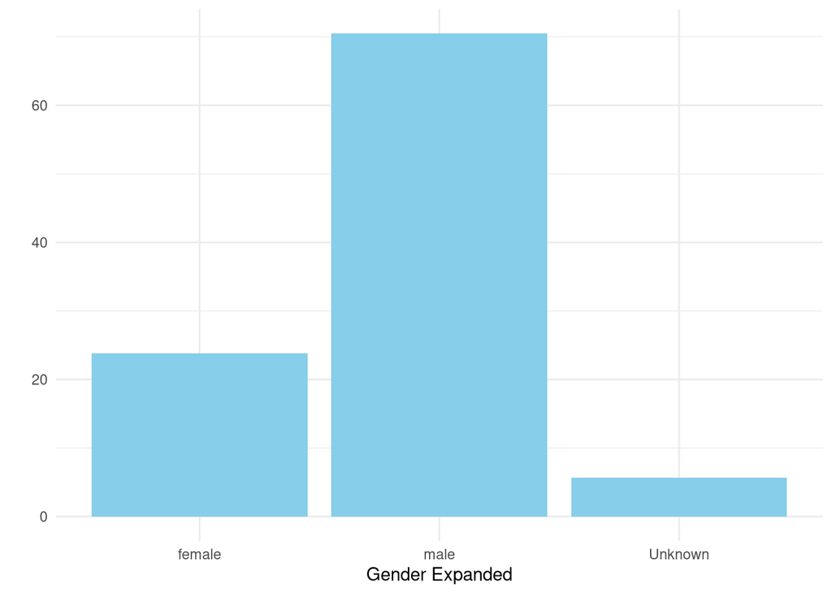

Figure 6: Distribution of individuals by gender

**Country**

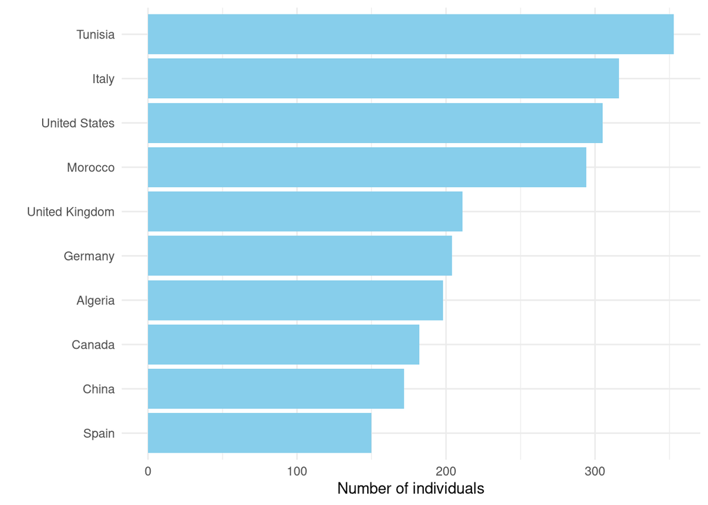

Figure 7: Distribution of individuals by country (top 10 excluding France)

# Data collection and cleaning process

This section outlines our strategy for constructing the database, which is divided into two main steps:

- **Scraping:** The first step consists of scraping data from the three main sources: Theses.fr, Sudoc, and IdRef.
- **Cleaning:** The second step entails processing and cleaning the raw data files to generate five relational tables.

The `R` code is available in the following [GitHub repository](https://github.com/tdelcey/becoming_economists/tree/main/FR/R). The following diagram illustrates the relationships between each script. If you encounter any errors or have questions regarding the data or the codes, please submit an [issue](https://github.com/tdelcey/becoming_economists/issues).

[interactive chart not shown]

## Scraping

### theses.fr

Theses records are registered in [theses.fr](https://theses.fr/) since 1985. Theses.fr data are also stored on [data.gouv.fr](https://www.data.gouv.fr/fr/datasets/theses-soutenues-en-france-depuis-1985/#/resources) website. They can be downloaded directly at this [URL](https://www.data.gouv.fr/fr/datasets/r/eb06a4f5-a9f1-4775-8226-33425c933272). The set of data we downloaded dated back from January 2024. The downloading_theses_fr.R script allows to download the `.csv` on data.gouv and to compress and store it in `.rds` format.

### Sudoc

We systematically collect metadata on French theses archived in the [Sudoc](https://www.sudoc.fr/) database, focusing on theses in economics. To identify theses in economics, we employ a dual-query approach:

- In the main query, we search for theses with a term beginning with “econo” in the “Note de Thèse” field, which specifies the discipline of the thesis.[^6] The search is restricted to the period from 1900 to 1985, as theses from subsequent years are systematically cataloged in [Theses.fr](https://theses.fr/). Here is the query allowing to retrieve thesis records.
- One issue specific to French history is that economic research was predominantly conducted within law faculties until the 1960s. Consequently, in a second query, we focus on theses where the term “droit” (law) appears in the field “Note de Thèse” and a word beginning with “econo” is present in the title. This search is restricted to the period 1900–1968, aiming to identify theses classified as law theses prior to 1968 that likely pertain to economics. Here is the query, allowing to retrieve thesis records.

The scraping_sudoc_id.R collects the thesis records URLs. Then, the scraping_sudoc_api.R allows to query the [Sudoc API](https://api.gouv.fr/documentation/api-sudoc) to retrieve structured metadata for each thesis, including information such as title, author, defence date, abstract, supervisor and other relevant details. These metadata are stored in an `.xml` file, which we then parse to extract the relevant information.[^7]

**Note**

scraping_sudoc_api.R utilizes parallel processing to accelerate data collection. It is designed with robust error and exception handling, ensuring efficient and reliable data retrieval. Moreover, the script is highly adaptable and can be easily used for other query types.

### IdRef

We utilize the IdRef identifiers collected from Sudoc and These.fr to retrieve additional information about entities, such as date of birth, gender, last known institutions, institutions’ preferred and alternate names, and years of existence. The scripts scraping_idref_person.R and scraping_idref_institution.R use the IdRef identifiers as input to query the [IdRef API](https://www.idref.fr/) and organize the retrieved information into structured tables.

## Cleaning

This section outlines the data cleaning process. Starting with the raw sources, we clean and harmonize the data to enable seamless merging of the two datasets, Sudoc and theses.fr. Following this, we construct our five data tables.

### Sudoc

The cleaning_sudoc.R script cleans the Sudoc data. It has two main objectives: managing duplicated identifiers and transforming the raw Sudoc data into a structured dataset. The process involves evaluating the data quality and restructuring the raw sources to ensure consistency and facilitate future merging with the theses.fr dataset.

The script handles duplicate identifiers, which fall into two categories:

- True duplicates: these occur when the same dissertation appears multiple times with identical identifiers and authors but differing defense dates. In such cases, the script retains the most recent record, as it is more likely to contain accurate metadata.
- False duplicates: these arise when the same identifier is linked to different authors, typically due to data entry errors from ABES. To resolve this, the script generates unique identifiers by appending a counter to the “national number thesis” field.

Most of the column of the final data are created here from the raw data. Two variables deserves a particular attention:

1. `year_defence`:
   - For some theses, multiple defense dates are retrieved for a single observation (line). In such cases, the earliest date is selected, as it is more likely to correspond to the original, unfinished thesis.
   - When dates differ significantly, manual checks are performed.
   - Anomalous dates outside the query range (1899–1985) are cleaned to maintain consistency.
2. `type`:
   - The `type` of the thesis is determined from various Sudoc metadata fields, reflecting the diversity of thesis types in the French system before the 1984 reform.
   - Thesis types are recoded into consistent categories, such as “Thèse d’État” and “Thèse de 3e cycle.” Entries that are not doctoral theses (e.g., master’s dissertations) are excluded to focus solely on relevant records.
   - If the thesis type cannot be determined, the variable is assigned the generic value “Thèse.”

**Warning**

The value “Thèse” of the `Type` variable is default value when we cannot identify a specific type of thesis.

Note that the value of `Language` are also standardized to align with ISO conventions, ensuring compatibility with theses.fr data.

The final dataset is divided into four tables that constitute the relational database: metadata, edge, individual, and institution. For entities without official identifiers, temporary IDs are generated to enable future identification and disambiguation. Temporary identifiers are under the format `temp_X_Y`, X representing the source of the original information (either “sudoc” or “thesesfr”) and Y the type of record, followed by a hash of the record that keeps the identifier stable across versions (see “Temporary identifiers” above).

### Theses.fr

The [cleaning_thesesfr.R](https://github.com/tdelcey/becoming_economists/blob/main/FR/R/thesesfr_cleaning.R) script focuses on cleaning and structuring metadata for theses related to economics, extracted from the theses.fr database. The methodology closely parallels the approach used for Sudoc: assessing data quality, standardizing raw data, and preparing the dataset for integration with Sudoc data.

A specific challenge addressed in this script involves filtering out theses that were incorrectly classified as economics-related in the query results. After resolving this issue, the script applies the same steps as those used for Sudoc data, including the categorization and harmonization of variables, to ensure consistency and facilitate merging.

As with the Sudoc data, temporary IDs are generated for entities lacking official identifiers from IdRef. These temporary IDs support future identification and disambiguation efforts.

### Merging

The merging_database.R script processes four types of tables—theses, edges, individuals, and institutions—generated from both the Sudoc and Theses.fr datasets. The script merges these tables in pairs to produce four intermediate merged tables. These intermediate data frames are subsequently cleaned and standardized in the following scripts.

### Metadata

The script cleaning_metadata.R is designed to clean and harmonize theses metadata. Metadata from Sudoc and theses.fr is derived from a variety of local institutions and individuals, which often results in inconsistencies and errors. This script focuses on addressing two major challenges: **language detection** and **duplicates identification**.

1. **Language detection:** To ensure consistency across metadata about titles and abstracts, the script employs the [cld3](https://docs.ropensci.org/cld3/reference/cld3.html) (Ooms 2024) and [fastText](https://mlampros.github.io/fastText/articles/language_identification.html) (Bojanowski et al. 2016) models for robust language identification. Key tasks include:
   - Verifying that titles and abstracts in French and English fields contain text in the correct languages. Discrepancies are resolved by reassigning text to appropriate fields.
   - Missing French or English titles and abstracts are supplemented using auxiliary columns from the scraped data (`title_other` and `abstract_other`) when relevant.
   - Titles and abstracts in full uppercase are converted to sentence case to enhance readability.
   - Placeholder text, irrelevant symbols, and uninformative entries are removed, with such entries replaced by missing values (NA).
2. **Duplicates:** Duplicated thesis records are a common issue, arising from cross-database redundancy (the same thesis may appear in both Sudoc and theses.fr) and intra-database redundancy (a thesis may be registered multiple times by different institutions within a single database). To address this, we developed a duplicates detection algorithm. The core of the process involves grouping titles by authors and comparing all possible title pairs within each group. We use the [Optimal String Alignment (OSA)](https://en.wikipedia.org/wiki/Damerau%E2%80%93Levenshtein_distance#Optimal_string_alignment_distance) distance as the primary metric for these comparisons. OSA estimates the number of operations (insertions, deletions, substitutions, and adjacent character transpositions) needed to align two strings. This method is implemented using the `stringdist` [package](https://CRAN.R-project.org/package=stringdist) (van der Loo 2014). We adjust the distance measure by the number of character in the title. Each potential duplicate is manually reviewed. In alignment with the project’s overall approach, we do not remove duplicates but instead flag them in a new column, `duplicates`. Table 6 provides an example of distinct theses in the sources that we flagged as duplicates.

Table 6: Example of theses identified as duplicates

| thesis_id | year_defence | author | author_id | title_fr | title_en | title_other | abstract_fr | abstract_en | abstract_other | language | language_2 | institution_thesis_name | institution_thesis_id | country | field | type | accessible | url | duplicates |
| --- | --- | --- | --- | --- | --- | --- | --- | --- | --- | --- | --- | --- | --- | --- | --- | --- | --- | --- | --- |
| 1962REN0G002 | 1962 | Michel, Pierre | 164479848 | L'Industrie du granit en Bretagne |  |  |  |  |  | fr |  | Université de Rennes. Faculté de droit et des sciences économiques (1896-1969) | 035647191 | France | Sciences économiques | Thèse |  | https://www.sudoc.fr/064184188 | ['1962REN0G002', 'temp_sudoc_thesis_6bd8c60326796d90', 'temp_sudoc_thesis_e9f3344929c6d473'] |
| temp_sudoc_thesis_6bd8c60326796d90 | 1962 | Michel, Pierre | 164479848 | L'industrie du granit en Bretagne |  |  |  |  |  | fr |  | Université de Rennes (1896-1969) | 074314807 | France | Sciences économiques | Thèse |  | https://www.sudoc.fr/072911255 | ['1962REN0G002', 'temp_sudoc_thesis_6bd8c60326796d90', 'temp_sudoc_thesis_e9f3344929c6d473'] |
| temp_sudoc_thesis_e9f3344929c6d473 | 1962 | Michel, Pierre | 164479848 | L'industrie du granit en Bretagne Annexe |  |  |  |  |  | fr |  | Université de Rennes (1896-1969) | 074314807 | France | Sciences économiques | Thèse |  | https://www.sudoc.fr/072911263 | ['1962REN0G002', 'temp_sudoc_thesis_6bd8c60326796d90', 'temp_sudoc_thesis_e9f3344929c6d473'] |

**Note**

Our script allows also for handling duplicates manually. If you spot an undetected duplicate, please [let us know](https://github.com/tdelcey/becoming_economists/issues).

### Institutions

The script cleaning_institution.R is dedicated to standardizing and improving the quality of institution data.

Institution names extracted from metadata have been stored in a separate table, `thesis_institution`. This script focuses on cleaning and standardizing these names to ensure consistency and accuracy. A key goal is replacing temporary institution identifiers (`id_sudoc_temp` or `id_thesesfr_temp`) created in merging_database.R with the official IdRef identifiers. This process relies on matching institution names and thesis defense dates, accounting for historical changes in institutional structures (e.g., the division of the University of Paris after 1968) and carefully handling ambiguous cases.

The script employs a manually curated table that associates regular expressions (RegEx) for institution names with their corresponding IdRef identifiers. The table also includes the institutions’ dates of creation (`date_of_birth`) and dissolution (`date_of_death`) to set clear temporal boundaries for identifier replacement. For instance, if the institution name matches “University of Paris” and:

- The thesis defense occurred before 1968, the identifier is replaced with [the identifier of the historic University of Paris](https://www.idref.fr/034526110), as it was the only university in Paris at the time.
- If the thesis is defended after 1968, the string “Université de Paris” is ambigous since it describes several distinct institutions. In this case, we kept the temporary identifier because we are not able to resolve the ambiguity.

### Individuals

The script cleaning_individuals.R is designed to standardize and enhance the quality of individual data.

The script first enriches individual records by incorporating information from the `idref_individual_table`, built from scraping_idref_person.R. When a name entity is linked to an IdRef identifier, supplementary details about the individual—such as organization affiliations, birth date, and relevant links (e.g., Wikipedia pages)—are added from the IdRef database. Additionally, raw names extracted from Sudoc or theses.fr are replaced with the standardized names provided by IdRef.

A key focus of the script is addressing inconsistencies in individual identifiers. Challenges include:

- Variations in names: The same individual may appear with slight name differences (e.g., “Jean A. Dupont” vs. “Jean Dupont”).
- Duplicate identifiers: A single individual may be associated with different identifiers across or within datasets (e.g., as an author in Sudoc in 1983 and as a jury member in theses.fr in 1999).

While the script strives to identify and group such cases, disambiguating individual identifiers is constrained by the risk of homonyms. For example, two individuals with identical names may represent distinct individuals. Due to this ambiguity, it is not possible to merge identifiers confidently.

To address potential ambiguities, the script introduces a new column, `homonym_of`, which groups potential homonyms. For each individual, the `homonym_of` field lists the identifiers of individuals with identical or highly similar names. This approach prevents premature merges while flagging possible relationships for users to investigate further.

Table 7: Example of individuals identified as homonym

| entity_id | entity_name | entity_firstname | gender | gender_expanded | birth | country_name | information | organization | last_date_org | start_date_org | end_date_org | other_link | homonym_of |
| --- | --- | --- | --- | --- | --- | --- | --- | --- | --- | --- | --- | --- | --- |
| 057545863 | Mignon | Valérie | female | female | 1970 | France | Professeure d'économie à l'Université Paris Nanterre (en 2023) | [] | [] | [] | [] | ['https://orcid.org/0000-0002-5578-1241', 'http://isni.org/isni/0000000117607245', 'http://data.bnf.fr/ark:/12148/cb13204778r#foaf:Person', 'http://viaf.org/viaf/44442640', 'https://fr.wikipedia.org/w… | ['057545863', 'temp_thesefr_individual_05de3433ae861998', 'temp_thesefr_individual_167b9aa4572ebfe7', 'temp_thesefr_individual_1be2086d9d9b1ebc', 'temp_thesefr_individual_2a7b678393e74123', 'temp_thes… |
| temp_thesefr_individual_05de3433ae861998 | Mignon | Valerie |  | female |  |  |  |  |  |  |  |  | ['057545863', 'temp_thesefr_individual_05de3433ae861998', 'temp_thesefr_individual_167b9aa4572ebfe7', 'temp_thesefr_individual_1be2086d9d9b1ebc', 'temp_thesefr_individual_2a7b678393e74123', 'temp_thes… |
| temp_thesefr_individual_167b9aa4572ebfe7 | Mignon | Valerie |  | female |  |  |  |  |  |  |  |  | ['057545863', 'temp_thesefr_individual_05de3433ae861998', 'temp_thesefr_individual_167b9aa4572ebfe7', 'temp_thesefr_individual_1be2086d9d9b1ebc', 'temp_thesefr_individual_2a7b678393e74123', 'temp_thes… |
| temp_thesefr_individual_bad833f61869c87a | Mignon | Valerie |  | female |  |  |  |  |  |  |  |  | ['057545863', 'temp_thesefr_individual_05de3433ae861998', 'temp_thesefr_individual_167b9aa4572ebfe7', 'temp_thesefr_individual_1be2086d9d9b1ebc', 'temp_thesefr_individual_2a7b678393e74123', 'temp_thes… |
| temp_thesefr_individual_e9c9356815e8c5a3 | Mignon | Valerie |  | female |  |  |  |  |  |  |  |  | ['057545863', 'temp_thesefr_individual_05de3433ae861998', 'temp_thesefr_individual_167b9aa4572ebfe7', 'temp_thesefr_individual_1be2086d9d9b1ebc', 'temp_thesefr_individual_2a7b678393e74123', 'temp_thes… |
| temp_thesefr_individual_1be2086d9d9b1ebc | Mignon | Valérie |  | female |  |  |  |  |  |  |  |  | ['057545863', 'temp_thesefr_individual_05de3433ae861998', 'temp_thesefr_individual_167b9aa4572ebfe7', 'temp_thesefr_individual_1be2086d9d9b1ebc', 'temp_thesefr_individual_2a7b678393e74123', 'temp_thes… |
| temp_thesefr_individual_2a7b678393e74123 | Mignon | Valérie |  | female |  |  |  |  |  |  |  |  | ['057545863', 'temp_thesefr_individual_05de3433ae861998', 'temp_thesefr_individual_167b9aa4572ebfe7', 'temp_thesefr_individual_1be2086d9d9b1ebc', 'temp_thesefr_individual_2a7b678393e74123', 'temp_thes… |
| temp_thesefr_individual_7ef56770e3bbf89d | Mignon | Valérie |  | female |  |  |  |  |  |  |  |  | ['057545863', 'temp_thesefr_individual_05de3433ae861998', 'temp_thesefr_individual_167b9aa4572ebfe7', 'temp_thesefr_individual_1be2086d9d9b1ebc', 'temp_thesefr_individual_2a7b678393e74123', 'temp_thes… |
| temp_thesefr_individual_a5503fd62ab262fa | Mignon | Valérie |  | female |  |  |  |  |  |  |  |  | ['057545863', 'temp_thesefr_individual_05de3433ae861998', 'temp_thesefr_individual_167b9aa4572ebfe7', 'temp_thesefr_individual_1be2086d9d9b1ebc', 'temp_thesefr_individual_2a7b678393e74123', 'temp_thes… |
| temp_thesefr_individual_b09c39e4ef750173 | Mignon | Valérie |  | female |  |  |  |  |  |  |  |  | ['057545863', 'temp_thesefr_individual_05de3433ae861998', 'temp_thesefr_individual_167b9aa4572ebfe7', 'temp_thesefr_individual_1be2086d9d9b1ebc', 'temp_thesefr_individual_2a7b678393e74123', 'temp_thes… |

Finally, the script enhances the gender column using data from the IdRef source. For individuals with missing gender values, we leverage French census data to predict gender. If a first name is associated with a single gender in more than 95% of cases, we assign that gender to the individual.

This approach has the advantage of simplicity but presents obvious limitations for handling some important cases (e.g., unisex names or cultural variations). The threshold of 95% is also arbitrary. To clarify the origin of the information, whether from IdRef or census data, we did not modify the `gender` column, and we created a new column, `gender_expanded.`

## References

Bojanowski, Piotr, Edouard Grave, Armand Joulin, Tomas Mikolov, Matthijs Douze, and Herve Jegou. 2016. “FastText.zip: Compressing Text Classification Models.” *arXiv Preprint arXiv:1612.03651*.

Ooms, Jeroen. 2024. *Cld3: Google’s Compact Language Detector 3*. https://docs.ropensci.org/cld3/.

van der Loo, M. P. J. 2014. “The Stringdist Package for Approximate String Matching.” *The R Journal* 6: 111–22. https://CRAN.R-project.org/package=stringdist.

## Footnotes

[^1]: While the focus is on France, both the database and its accompanying documentation are presented in English. This decision reflects its integration into a larger initiative, which seeks to establish a comprehensive global repository of Ph.D. dissertations in economics.
[^2]: The edges data are provided in two formats: (1) a ready-to-use format with cleaned and standardized information; and (2) a more extensive format that allows for comparison between the original collected data and the results of the cleaning process.
[^3]: See the English description of the licence [here](https://www.etalab.gouv.fr/wp-content/uploads/2018/11/open-licence.pdf).
[^4]: This corresponds to the reform of French PhD and the implementation of the “new regime”.
[^5]: Exceptions were made for minimal transformations, such as replacing fully uppercase titles and abstracts with standardized capitalization, or correcting errors, such as changing the language of a title or abstract when it was mistakenly assigned.
[^6]: This RegEx captures terms such as “économie” and “Economique” because Sudoc’s search function is case-insensitive and disregards accents.
[^7]: The structure of the `.xml` used by the ABES is explained [here](https://documentation.abes.fr/sudoc/manuels/administration/aidewebservices/index.html#Sudoc%20MarcXML).